# Bayesian modeling and prediction for movies

## Setup

### Load packages

```r
library(ggplot2)
library(dplyr)
library(statsr)
library(BAS)
```

### Load data

```r
load("movies.Rdata")
```

## Part 1: Data

These data are a random sample of movies from two survey based movie ratings websites. Because these data are a random sample they are generalizable, but only to the two movie databases from which they were obtained. The individuals who provide insights to these databases are not selected randomly and do so by choice. This means that there might be a bias in terms of who chooses to participate in the ratings. With that said, I would still use these data to attempt to predict future ratings on these sites as it can be assumed that all ratings are affected by the same biases.

No causal relationships should be drawn from these data. These data were voluntarily provided, i.e. observational data, therfore random assignment was not used.

## Part 2: Data manipulation

### Create Feature Film Field

```r
movies <- movies %>% mutate(feature_film = "yes")
movies$feature_film[movies$title_type != 'Feature Film'] <- 'no'
```

### Create Drama Field

```r
movies <- movies %>% mutate(drama = ifelse(movies$genre == 'Drama', 'yes', 'no'))
```

### Create MPAA_Rating_R Field

```r
movies <- movies%>% mutate(mpaa_rating_R = ifelse(movies$mpaa_rating == 'R', 'yes', 'no'))
```

### Create season fields

```r
oscar_months = c(10, 11, 12)
summer_months = c(5, 6, 7, 8)

movies <- movies%>% mutate(oscar_season = ifelse(movies$thtr_rel_month %in% oscar_months, 'yes', 'no'))
movies <- movies%>% mutate(summer_season = ifelse(movies$thtr_rel_month %in% summer_months, 'yes', 'no'))
```

## Part 3: Exploratory data analysis

### Feature Films

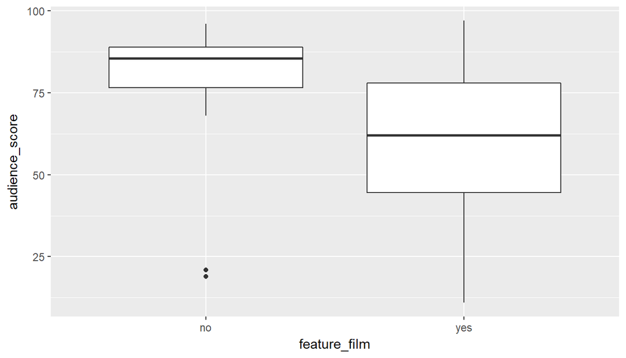

```r
ggplot(data=movies, aes(feature_film, audience_score)) + geom_boxplot()
```

```r
movies %>% group_by(feature_film) %>%
    summarise(median_score = median(audience_score),
              min_score = min(audience_score),
              max_score = max(audience_score),
              iqr = IQR(audience_score),
              count = n())
```

```
## # A tibble: 2 x 6
##   feature_film median_score min_score max_score   iqr count
##   <chr>               <dbl>     <dbl>     <dbl> <dbl> <int>
## 1 no                   85.5        19        96  12.5    60
## 2 yes                  62          11        97  33.5   591
```

The median score for feature films is much lower than non-feature films. While the minimum and maximum scores for the two categories are fairly similar, the IQR for feature films is much broader. This means there is more variability in feature film scores and those scores seem to be lower than their non-feature counterparts. There are also far more feature films, which could explain some of the varibility in scores.

### Dramas

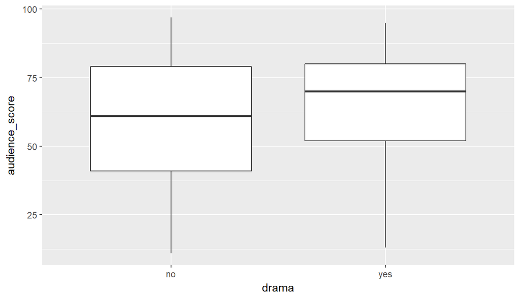

```r
ggplot(data=movies, aes(drama, audience_score)) + geom_boxplot()
```

```r
movies %>% group_by(drama) %>%
    summarise(median_score = median(audience_score),
              min_score = min(audience_score),
              max_score = max(audience_score),
              iqr = IQR(audience_score),
              count = n())
```

```
## # A tibble: 2 x 6
##   drama median_score min_score max_score   iqr count
##   <chr>        <dbl>     <dbl>     <dbl> <dbl> <int>
## 1 no              61        11        97    38   346
## 2 yes             70        13        95    28   305
```

Dramas have a higer median auduence score than non-drama movies although the difference is not as extreme as for the feature film category. The IQR of non-dramas is broader than dramas. This could be reflective of the fact that mutiple genres are lumped into one group. It is possible that one group of movies routinely scores lower or higher hence the broader range in scores for non-dramas. The minimum and maximum scores for the two groups are fairly similar.

### R Rated Movies

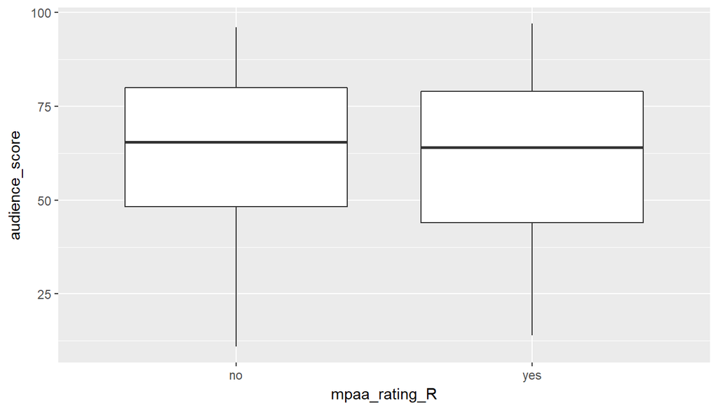

```r
ggplot(data=movies, aes(mpaa_rating_R, audience_score)) + geom_boxplot()
```

```r
movies %>% group_by(mpaa_rating_R) %>%
    summarise(median_score = median(audience_score),
              min_score = min(audience_score),
              max_score = max(audience_score),
              iqr = IQR(audience_score),
              count = n())
```

```
## # A tibble: 2 x 6
##   mpaa_rating_R median_score min_score max_score   iqr count
##   <chr>                <dbl>     <dbl>     <dbl> <dbl> <int>
## 1 no                    65.5        11        96  31.8   322
## 2 yes                   64          14        97  35     329
```

There is virtually no difference between R-rated and non-R-rated movies. The median values are very close and so are the minimum and maximum values. There are also a very similar number of movies in each category. It is possible that not much of the variability in audience score will be described by R rating.

### Oscar Season Movies

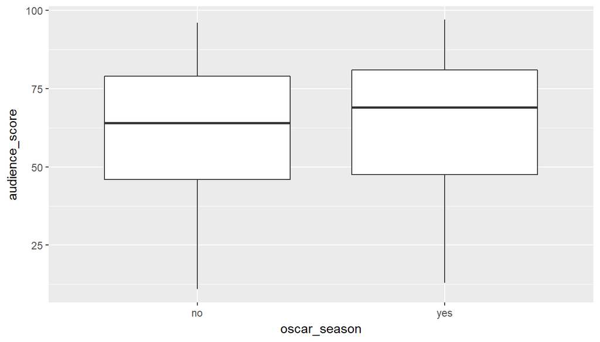

```r
ggplot(data=movies, aes(oscar_season, audience_score)) + geom_boxplot()
```

```r
movies %>% group_by(oscar_season) %>%
    summarise(median_score = median(audience_score),
              min_score = min(audience_score),
              max_score = max(audience_score),
              iqr = IQR(audience_score),
              count = n())
```

```
## # A tibble: 2 x 6
##   oscar_season median_score min_score max_score   iqr count
##   <chr>               <dbl>     <dbl>     <dbl> <dbl> <int>
## 1 no                     64        11        96  33     460
## 2 yes                    69        13        97  33.5   191
```

The audience score values for Oscar vs. non-Oscar season movies are very similar. The Oscar season movies do have a higher median score but not overwhelmingly so. The IQR for each category is also strikingly similar. Initially I might have suspected that Oscar season movies would have higher scores but the fact that Oscar season and the holiday season overlap means that many movies that may be “family oriented” and not necessarily high caliber are being released at the same time potentially obfuscating any signal from Oscar worthy movies.

### Summer Season Movies

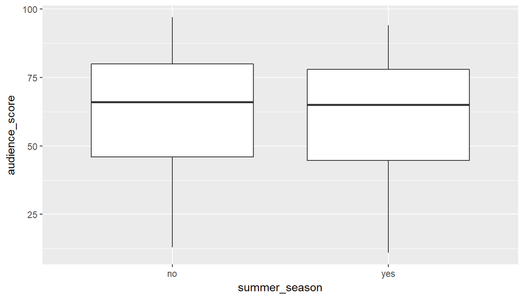

```r
ggplot(data=movies, aes(summer_season, audience_score)) + geom_boxplot()
```

```r
movies %>% group_by(summer_season) %>%
    summarise(median_score = median(audience_score),
              min_score = min(audience_score),
              max_score = max(audience_score),
              iqr = IQR(audience_score),
              count = n())
```

```
## # A tibble: 2 x 6
##   summer_season median_score min_score max_score   iqr count
##   <chr>                <dbl>     <dbl>     <dbl> <dbl> <int>
## 1 no                      66        13        97  34     443
## 2 yes                     65        11        94  33.2   208
```

There is very little difference in the scores for summer and non-summer season movies. The median, minimum, and maximum scores are similar between categories and so are the IQRs. Summer season does not seem to be a good predictor of audience score.

## Part 4: Modeling

```r
#get a dataframe with only the fields we are interested in modeling
model_movies <- movies %>% select(audience_score, feature_film, drama, runtime, mpaa_rating_R, thtr_rel_year, oscar_season, summer_season, imdb_rating, imdb_num_votes, critics_score, best_pic_nom, best_pic_win, best_actor_win, best_actress_win, best_dir_win, top200_box)

model_movies <- na.omit(model_movies)

library(MASS)
#declare the full model and then use BIC to pick the best moddel according to BIC
aud_score_model = lm(audience_score ~ ., data=model_movies)
best_BIC = stepAIC(aud_score_model, k=log(650), trace=0)
summary(best_BIC)
```

```
##
## Call:
## lm(formula = audience_score ~ runtime + imdb_rating + critics_score,
##     data = model_movies)
##
## Residuals:
##     Min      1Q  Median      3Q     Max
## -26.998  -6.565   0.557   5.475  52.448
##
## Coefficients:
##                Estimate Std. Error t value Pr(>|t|)
## (Intercept)   -33.28321    3.21939 -10.338  < 2e-16 ***
## runtime        -0.05362    0.02107  -2.545  0.01117 *
## imdb_rating    14.98076    0.57735  25.947  < 2e-16 ***
## critics_score   0.07036    0.02156   3.263  0.00116 **
## ---
## Signif. codes:  0 '***' 0.001 '**' 0.01 '*' 0.05 '.' 0.1 ' ' 1
##
## Residual standard error: 10.04 on 646 degrees of freedom
## Multiple R-squared:  0.7549, Adjusted R-squared:  0.7538
## F-statistic: 663.3 on 3 and 646 DF,  p-value: < 2.2e-16
```

Using BIC to select the best model results in a model with runtime, imdb_rating, and critics_score as variables. Runtime is the only variable negatively correlated with audience score, but coefficient is very small so for every minute in length, the score is predicted to drop by 0.05 points all things held equal. Both imdb_rating and critics_score have positive coefficients. While critics_score doesn’t seem to influence audience_score much, a 0.07 point rise for each unit rise in critics_score, the audience score rises nearly 15 points for every unit increase in imdb_rating.

When looking at the adjusted $R^2$, over 75% of the variability in audience scores is accounted for by this model.

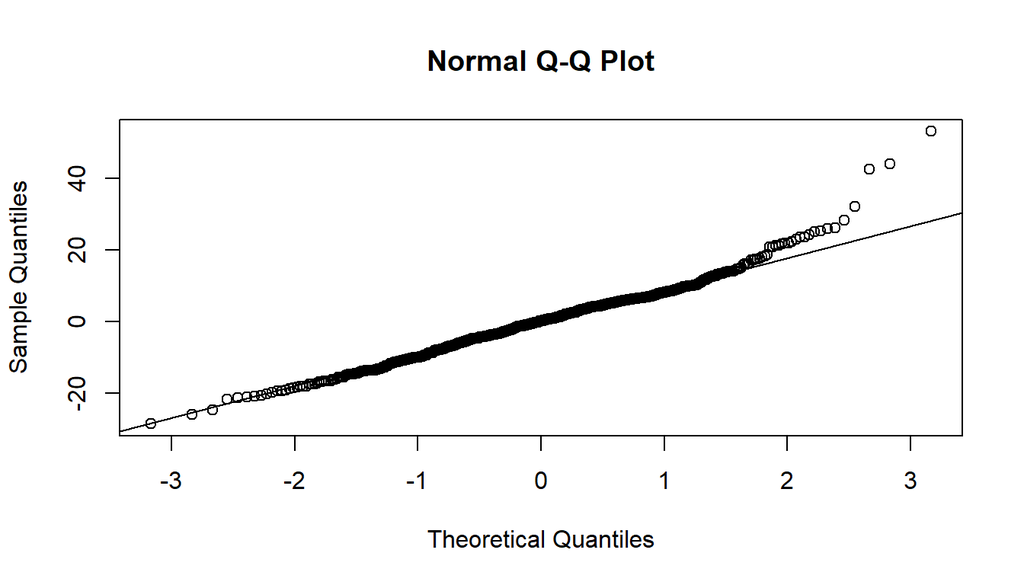

```r
qqnorm(resid(aud_score_model)) ; qqline(resid(aud_score_model))
```

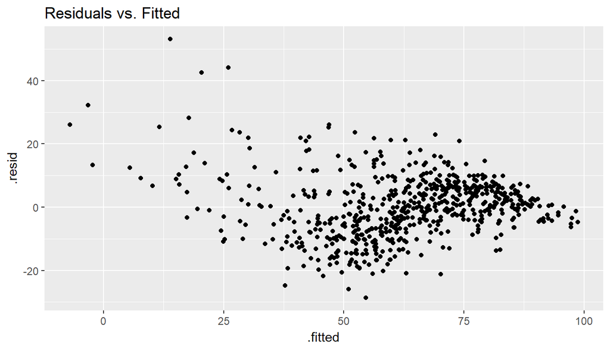

```r
ggplot(aud_score_model) + geom_point(aes(x=.fitted, y=.resid)) + ggtitle("Residuals vs. Fitted")
```

## Part 5: Prediction

To test this we will compare this to the recent best picture winner The Shape of Water. This has a critics score of 92, and imdb_rating of 7.4 and a runtime of 123 minutes:

The rotten tomatoes data can be found here: https://www.rottentomatoes.com/m/the_shape_of_water_2017/ The data for imdb data and runtime can be found here: https://www.rottentomatoes.com/m/the_shape_of_water_2017/ The BoxOfficeMojo data can be found: http://www.boxofficemojo.com/movies/?id=theshapeofwater.htm

```r
new_df = data.frame(critics_score = c(92), imdb_rating = c(7.4), runtime = c(123), feature_film = c('yes'), drama = c('yes'), mpaa_rating_R = c('yes'), thtr_rel_year = c(2017), oscar_season = c('yes'), summer_season = c('no'), imdb_num_votes = c(217801), best_pic_nom = c('yes'), best_pic_win=c('yes'), best_actor_win = c('no'), best_actress_win = c('no'), best_dir_win = c('yes'), top200_box = c('no'))

predicted_score = predict(best_BIC, new_df, interval = 'predict')
predicted_score
```

```
##       fit      lwr     upr
## 1 77.4526 57.69069 97.2145
```

According to our best BIC model, the audience score is predicted to be 77.4 with a 95% confidence interval of 57.7-97.2. The actual audience score is 73 as of 6/3/2018.

I am curious if, by using Bayesian Model Averaging, if the model will predict more closely to the actual audience score.

```r
#create a BMA model
bma_aud_score = bas.lm(audience_score ~ ., data=model_movies, prior = 'BIC', modelprior = uniform())
model_coef = coef(bma_aud_score)
model_coef
```

```
##
##  Marginal Posterior Summaries of Coefficients:
##
##  Using  BMA
##
##  Based on the top  65536 models
##                      post mean   post SD     post p(B != 0)
## Intercept             6.235e+01   3.946e-01   1.000e+00
## feature_filmyes      -1.047e-01   5.643e-01   6.537e-02
## dramayes              1.604e-02   1.939e-01   4.320e-02
## runtime              -2.568e-02   3.118e-02   4.697e-01
## mpaa_rating_Ryes     -3.036e-01   7.032e-01   1.998e-01
## thtr_rel_year        -4.533e-03   1.819e-02   9.069e-02
## oscar_seasonyes      -8.035e-02   3.773e-01   7.506e-02
## summer_seasonyes      8.705e-02   3.831e-01   8.042e-02
## imdb_rating           1.498e+01   7.310e-01   1.000e+00
## imdb_num_votes        2.081e-07   1.313e-06   5.774e-02
## critics_score         6.297e-02   3.028e-02   8.886e-01
## best_pic_nomyes       5.068e-01   1.568e+00   1.312e-01
## best_pic_winyes      -8.503e-03   8.479e-01   3.985e-02
## best_actor_winyes    -2.877e-01   8.318e-01   1.443e-01
## best_actress_winyes  -3.088e-01   9.057e-01   1.413e-01
## best_dir_winyes      -1.195e-01   6.227e-01   6.694e-02
## top200_boxyes         8.648e-02   7.050e-01   4.762e-02
```

```r
#print 95% credible interval of coefficients
confint(model_coef)
```

```
##                              2.5%        97.5%          beta
## Intercept            6.154304e+01 6.308588e+01  6.234769e+01
## feature_filmyes     -1.091696e+00 0.000000e+00 -1.046908e-01
## dramayes             0.000000e+00 0.000000e+00  1.604413e-02
## runtime             -8.296259e-02 0.000000e+00 -2.567772e-02
## mpaa_rating_Ryes    -2.173195e+00 0.000000e+00 -3.036174e-01
## thtr_rel_year       -5.260078e-02 0.000000e+00 -4.532635e-03
## oscar_seasonyes     -9.584419e-01 8.839411e-04 -8.034940e-02
## summer_seasonyes    -6.953114e-03 1.043700e+00  8.704545e-02
## imdb_rating          1.368784e+01 1.654556e+01  1.498203e+01
## imdb_num_votes      -1.806836e-07 1.000788e-06  2.080713e-07
## critics_score        0.000000e+00 1.057104e-01  6.296648e-02
## best_pic_nomyes      0.000000e+00 4.948632e+00  5.068035e-01
## best_pic_winyes      0.000000e+00 0.000000e+00 -8.502836e-03
## best_actor_winyes   -2.540392e+00 0.000000e+00 -2.876695e-01
## best_actress_winyes -2.791459e+00 0.000000e+00 -3.088382e-01
## best_dir_winyes     -1.417504e+00 2.366410e-02 -1.195011e-01
## top200_boxyes       -3.523426e-04 1.132912e-01  8.648185e-02
## attr(,"Probability")
## [1] 0.95
## attr(,"class")
## [1] "confint.bas"
```

```r
#predict score using Best Predictive Model (BPM)
bma_predict = predict(bma_aud_score, newdata=new_df, estimator = 'BPM')
bma_predict$fit
```

```
## [1] 77.83411
## attr(,"model")
##  [1]  0  1  2  3  5  6  7  9 10 11 12 16
## attr(,"best")
## [1] 61531
```

Using this method, the model predicts a score of 77.8 which is very near our original prediction but slightly further away than using the model predicted using BIC.

## Part 6: Conclusion

Summarizing my findings from above, it seems that, using BIC, the three variables that are most influential when predicing audience score are imdb_rating, critcs score, and runtime. I find it interesting that runtime is negatively correlated with audience score in the model, indicating that audiences tend to prefer shorter movies. I don’t find it hat suprising that imdb rating has the most influence on predicting audience score. I would actually expect that there are a fair number of users who rate the movies on both sites, meaning that the audinece score and imdb score might have the same individuals providing input.

I thought it was a nice validation that the BPM of a BMA model predicted a score that was very near the score derived using the BIC derived model. This does make sense, but it also gives me comfort to know that mutliple methods are coming up with the same answers.

In all, I think that this model does a very good job of predicting audience scores on Rotten Tomatoes. One thing I would look into is if there was a way to identify users of both Rotten Tomatoes and IMDB and somehow remove their rating from the model. Otherwise I believe that these variables to a great job of getting at the information that we want to know.